# Practicum 3

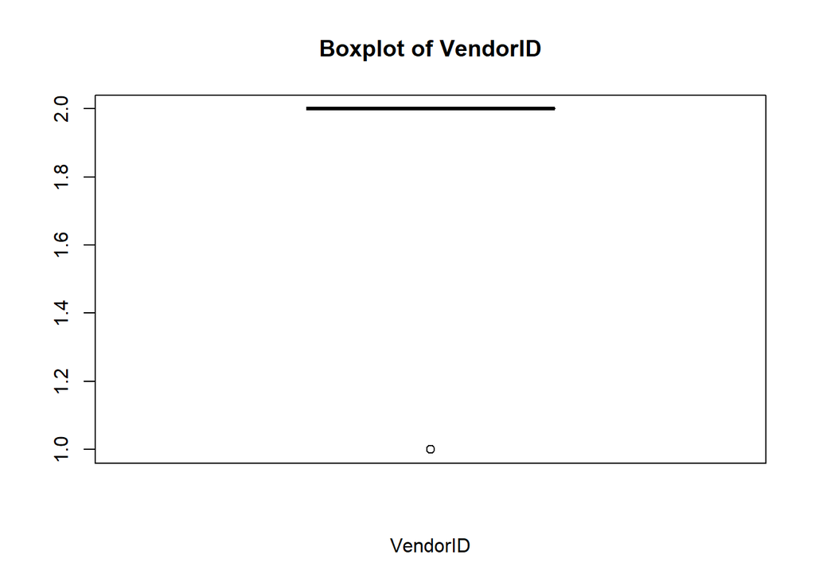

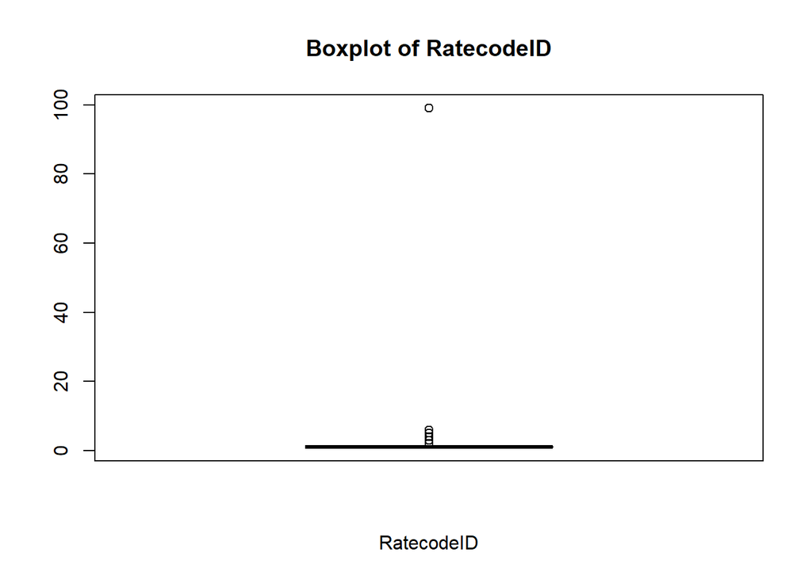

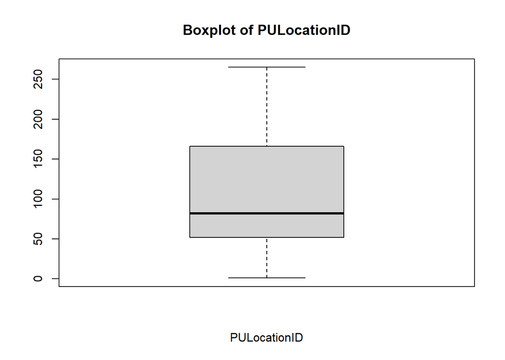

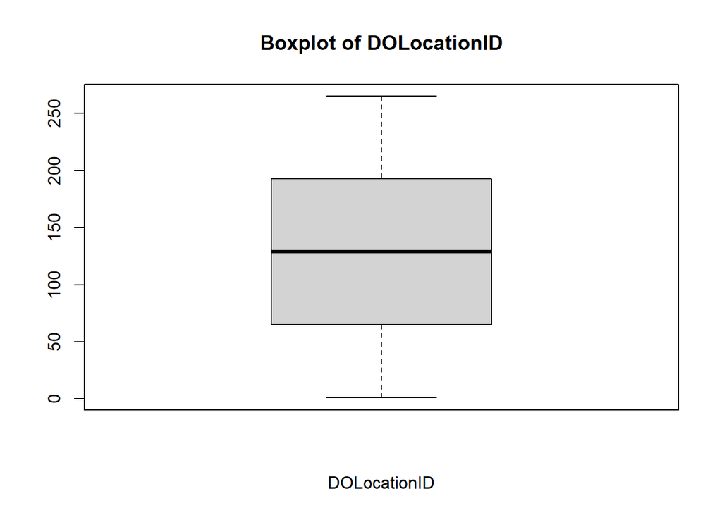

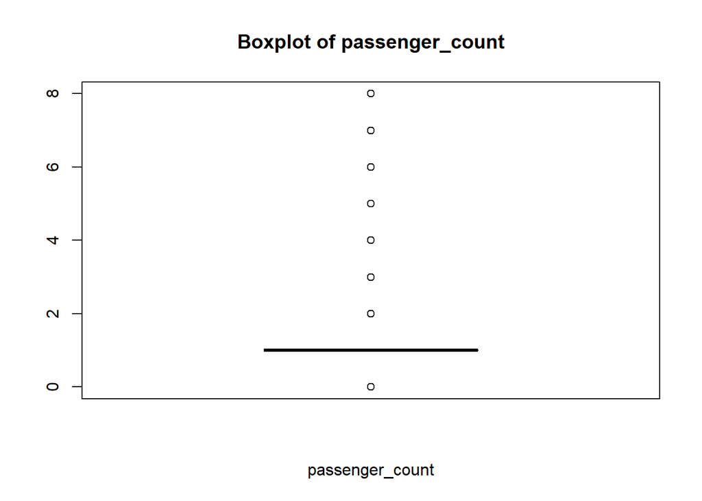

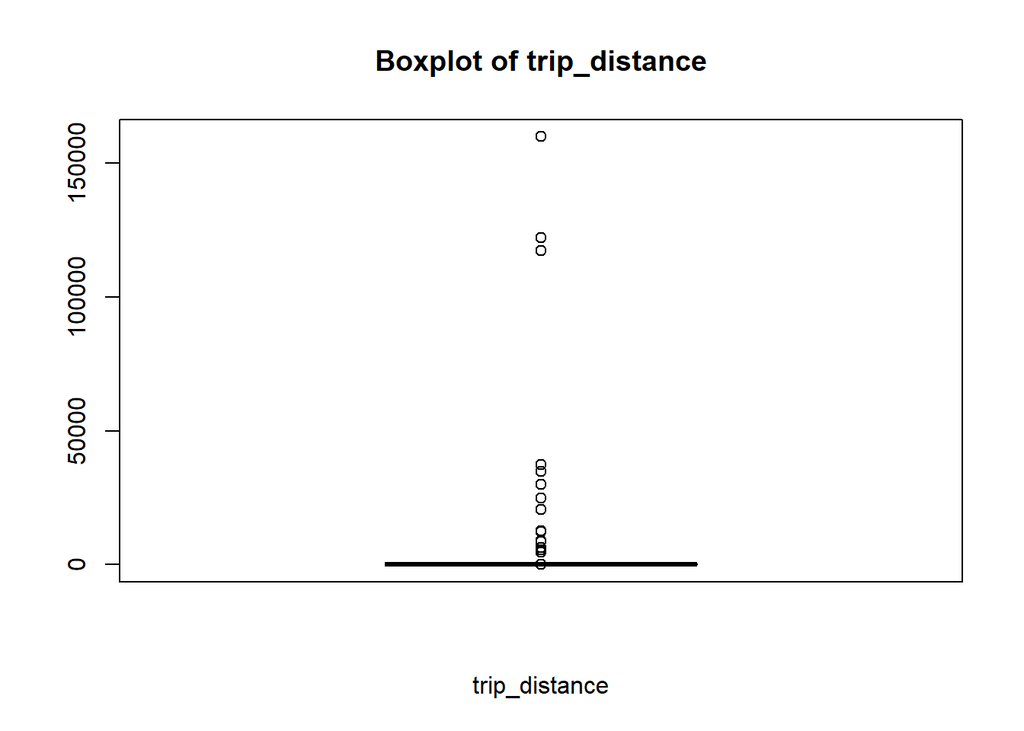

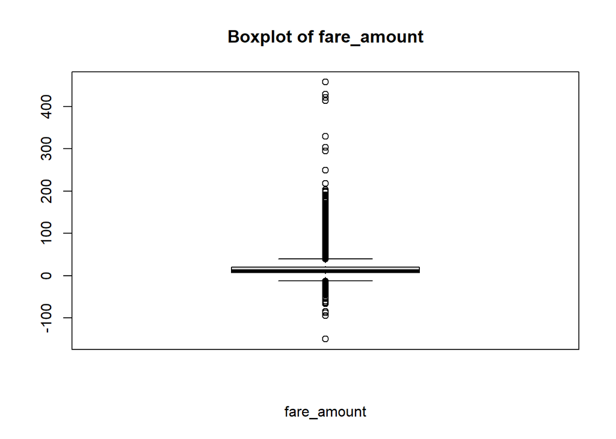

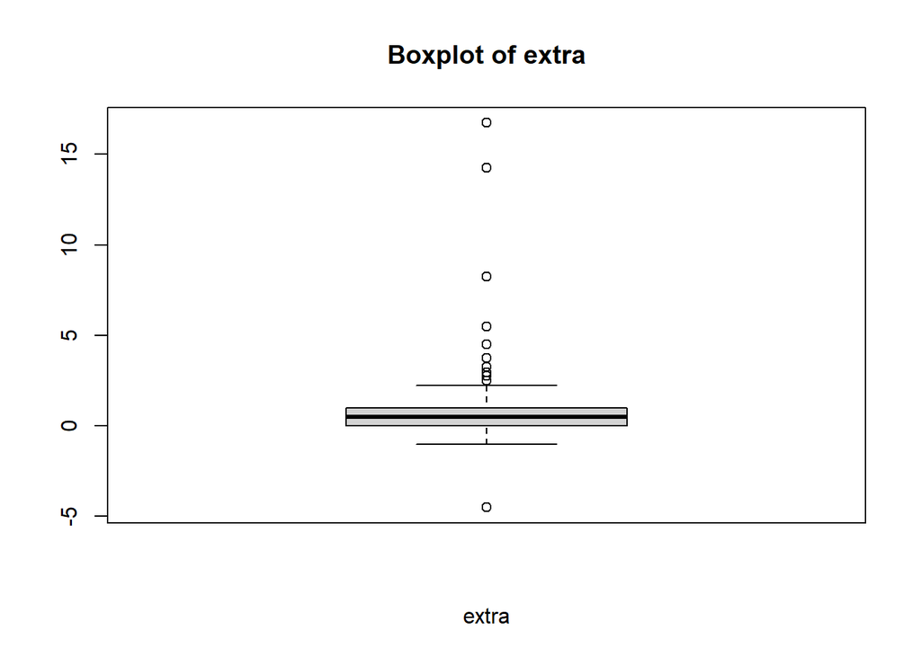

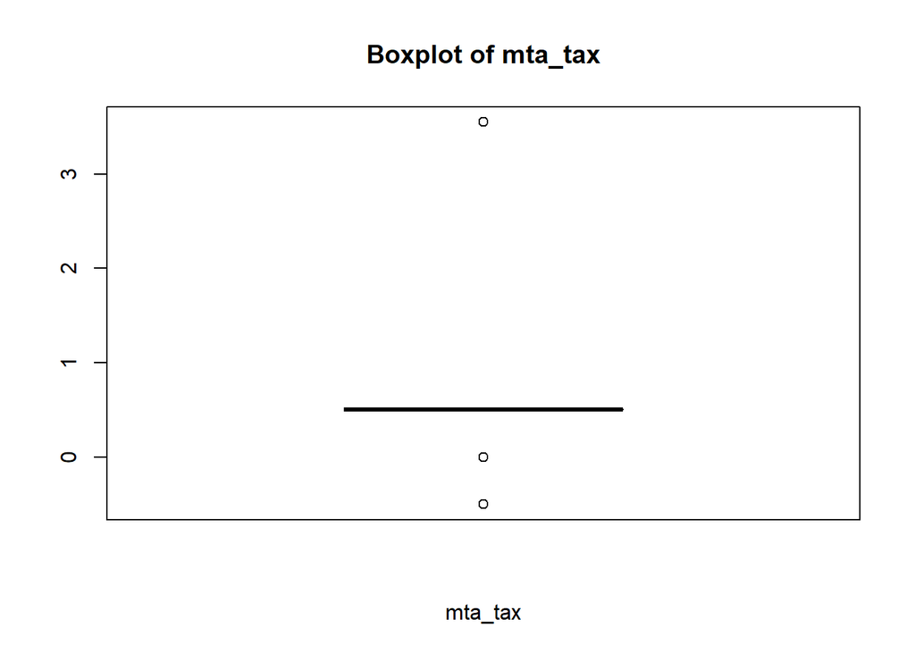

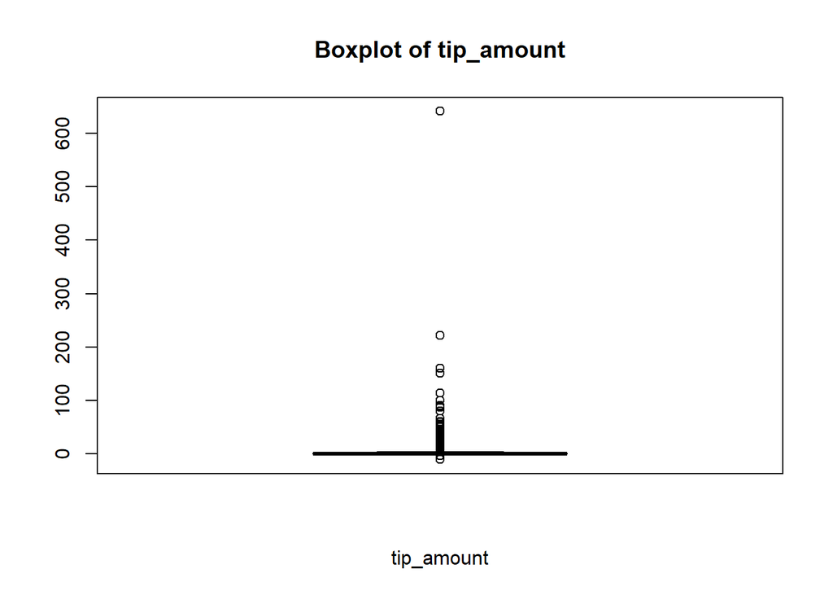

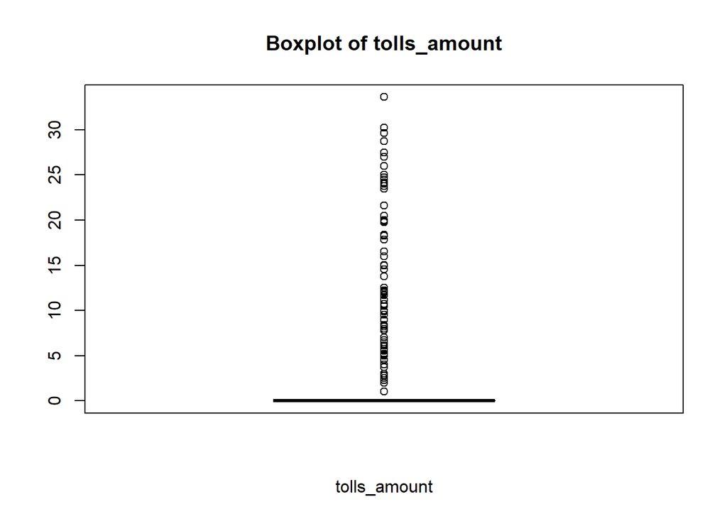

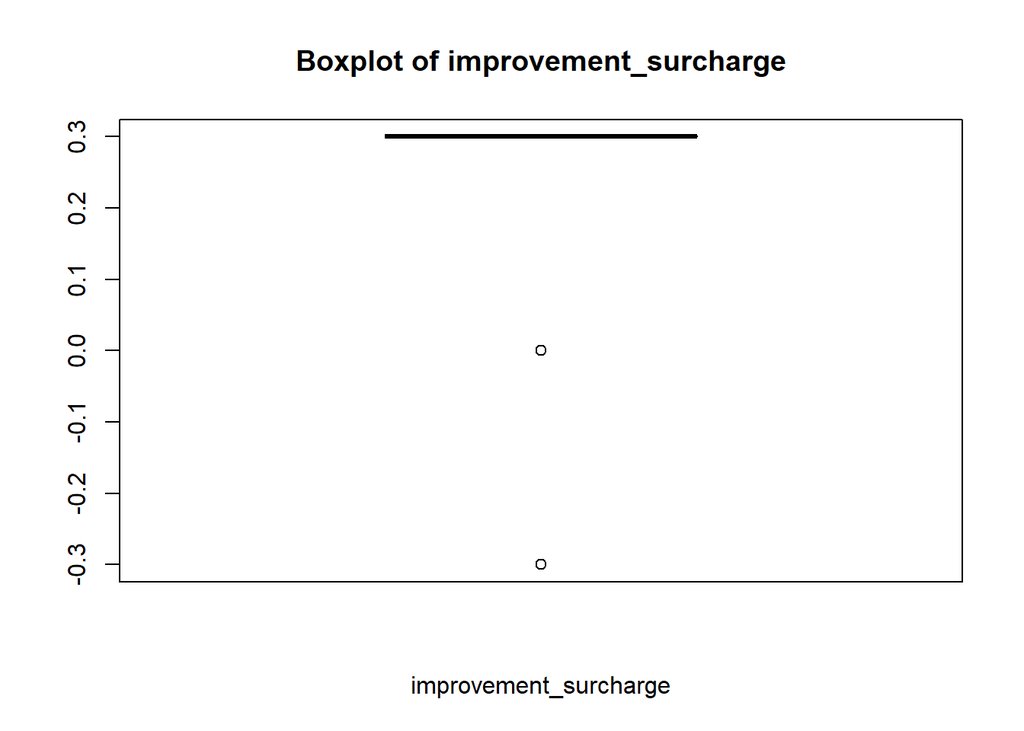

[4 more figures not shown]

```r
# function to plot boxplots fo outlier
box_plots <- function(numeric_vars) {
  for(i in 1:length(numeric_vars)) {
    column_name <- colnames(numeric_vars)[i]
    boxplot(taxi_data[[column_name]], main = paste("Boxplot of", column_name),
         xlab = column_name)
  }
}
# plotting boxplots for numeric variables
box_plots(numeric_vars)
```

```r
# correlation of dataset
cor(numeric_vars, use = "pairwise.complete.obs")
```

```
##                            VendorID   RatecodeID  PULocationID  DOLocationID
## VendorID               1.0000000000 -0.023560330 -0.0223133623 -0.0001776707
## RatecodeID            -0.0235603299  1.000000000  0.0692916300  0.0376480326
## PULocationID          -0.0223133623  0.069291630  1.0000000000  0.1566135962
## DOLocationID          -0.0001776707  0.037648033  0.1566135962  1.0000000000
## passenger_count        0.0882095541 -0.005321159  0.0121354178  0.0105786845
## trip_distance          0.0093559000  0.020064986 -0.0006173308 -0.0007438620
## fare_amount           -0.0277272756  0.133609506  0.1133277595  0.0667782110
## extra                 -0.2507772395 -0.091855778  0.0859729394  0.0123915859
## mta_tax                0.0071548024 -0.685183758 -0.1075670216  0.0090860753
## tip_amount             0.0363694555  0.019239251 -0.0059373283  0.0869352748
## tolls_amount          -0.0127143594  0.031477555  0.0541722730  0.0243924715
## improvement_surcharge  0.0545554684 -0.274315052 -0.0301498289  0.0039839953
## total_amount          -0.0138693494  0.106472212  0.1085539198  0.0930921858
## payment_type          -0.0097397897  0.031241633 -0.0135234455 -0.0749123046
## trip_type             -0.0269121071  0.890175993  0.0699829220  0.0340850588
## congestion_surcharge   0.0142011985 -0.050453073 -0.0306828799  0.3114156217
##                       passenger_count trip_distance fare_amount        extra
## VendorID                 0.0882095541  0.0093559000 -0.02772728 -0.250777240
## RatecodeID              -0.0053211594  0.0200649862  0.13360951 -0.091855778
## PULocationID             0.0121354178 -0.0006173308  0.11332776  0.085972939
## DOLocationID             0.0105786845 -0.0007438620  0.06677821  0.012391586
## passenger_count          1.0000000000 -0.0005636747 -0.01040701 -0.015676261
## trip_distance           -0.0005636747  1.0000000000  0.01319701  0.009599995
## fare_amount             -0.0104070089  0.0131970076  1.00000000  0.450107688
## extra                   -0.0156762614  0.0095999951  0.45010769  1.000000000
## mta_tax                  0.0010518049 -0.0111266695 -0.44935487 -0.648568655
## tip_amount               0.0055366967 -0.0007984680  0.05804439 -0.145518861
## tolls_amount            -0.0077607240  0.0051766325  0.42308186  0.179458297
## improvement_surcharge    0.0030662929  0.0001248925 -0.02249172 -0.078454377
## total_amount            -0.0074573923  0.0127833888  0.97876257  0.458827060
## payment_type             0.0141746696 -0.0093190285 -0.14564626 -0.067204679
## trip_type               -0.0049499578  0.0021874318  0.10114602 -0.099381874
## congestion_surcharge     0.0091702117  0.0292499567  0.21635883  0.239913952
##                            mta_tax   tip_amount tolls_amount
## VendorID               0.007154802  0.036369456 -0.012714359
## RatecodeID            -0.685183758  0.019239251  0.031477555
## PULocationID          -0.107567022 -0.005937328  0.054172273
## DOLocationID           0.009086075  0.086935275  0.024392472
## passenger_count        0.001051805  0.005536697 -0.007760724
```

[output cut: 30 more lines]

```
## RatecodeID             0.890175993         -0.050453073
## PULocationID           0.069982922         -0.030682880
## DOLocationID           0.034085059          0.311415622
## passenger_count       -0.004949958          0.009170212
## trip_distance          0.002187432          0.029249957
## fare_amount            0.101146025          0.216358831
## extra                 -0.099381874          0.239913952
## mta_tax               -0.740339427          0.057623666
## tip_amount             0.002388457          0.276455719
## tolls_amount           0.005488272          0.002543840
## improvement_surcharge -0.312184419          0.043203538
## total_amount           0.071748166          0.333636608
## payment_type           0.033535619         -0.182280450
## trip_type              1.000000000         -0.050335742
## congestion_surcharge  -0.050335742          1.000000000
```

Based on the correlation data, there is multicollinearity present. fare_amount and total_amount have colinearity in this data with a correlation of 0.97876257, mta_tax and trip_type also have colinearity with a correlation of -0.740339427, and RatecodeID and trip_type have colinearity of 0.890175993.

### Feature selection

Not all variables are useful for the prediction of the target variable, tip_amount. The following variables will not useful to determine tip amount: VendorID, store_and_fwd_flag, ehail_fee, trip_type, and tolls_amount. VendorID is removed from as a predictor because the provider of taxi would not impact the amount of tips received, store_and_fwd_flag was removed because its a variable that indicates whether the record was stored or not and is not relevant to tip_amount, ehail_fee was removed because it only contains na values, trip_type determines whether the cab is street hail or dispatch which would not impact tip amount, and tolls_amount was determined to be irrelevant to tip amount because regarding of the trip destination tolls are going to be used.

```r
predictor_vars <- taxi_data |>
  select(-c(VendorID, store_and_fwd_flag, ehail_fee, trip_type, tolls_amount))

head(predictor_vars)
```

|  | lpep_pickup_datetime | lpep_dropoff_datetime | RatecodeID | PULocationID | DOLocationID | passenger_count | trip_distance | fare_amount | extra | mta_tax | tip_amount | improvement_surcharge | total_amount | payment_type | congestion_surcharge |
| --- | --- | --- | --- | --- | --- | --- | --- | --- | --- | --- | --- | --- | --- | --- | --- |
| 1 | 02/01/2020 12:00:00 AM | 02/01/2020 12:13:00 AM | NA | 108 | 55 | NA | 3.06 | 17.69 | 2.75 | 0.0 | 0.00 | 0.3 | 20.74 | NA | NA |
| 2 | 02/01/2020 12:00:09 AM | 02/01/2020 12:04:09 AM | 1 | 65 | 97 | 1 | 0.94 | 5.00 | 0.50 | 0.5 | 0.00 | 0.3 | 6.30 | 2 | 0 |
| 3 | 02/01/2020 12:00:15 AM | 02/01/2020 12:11:39 AM | 1 | 168 | 167 | 1 | 2.68 | 10.50 | 0.50 | 0.5 | 0.00 | 0.3 | 11.80 | 2 | 0 |
| 4 | 02/01/2020 12:00:19 AM | 02/01/2020 12:24:28 AM | 1 | 255 | 49 | 1 | 4.83 | 18.50 | 0.50 | 0.5 | 0.00 | 0.3 | 19.80 | 2 | 0 |
| 5 | 02/01/2020 12:00:23 AM | 02/01/2020 12:05:55 AM | 1 | 41 | 41 | 1 | 0.85 | 5.50 | 0.50 | 0.5 | 1.36 | 0.3 | 8.16 | 1 | 0 |
| 6 | 02/01/2020 12:00:26 AM | 02/01/2020 12:11:27 AM | 1 | 95 | 121 | 1 | 2.58 | 10.50 | 0.50 | 0.5 | 0.00 | 0.3 | 11.80 | 1 | 0 |

## Question 2

### Data Preprocessing

```r
# Remove rows with missing values in key columns
taxi_data_clean <- taxi_data %>%
  filter(!is.na(VendorID),
         !is.na(RatecodeID),
         !is.na(passenger_count),
         !is.na(payment_type),
         !is.na(trip_type),
         !is.na(congestion_surcharge)) %>%
  # Remove rows with negative fare, extra, mta_tax, improvement_surcharge, and total_amount as they are inconsistent with data dictionary
  filter(fare_amount >= 0,
         extra >= 0,
         mta_tax >= 0,
         improvement_surcharge >= 0,
         total_amount >= 0) %>%
  # Remove potential outliers (for now, anything outside 99th percentile)
  filter(fare_amount <= quantile(fare_amount, 0.99),
         extra <= quantile(extra, 0.99),
         mta_tax <= quantile(mta_tax, 0.99),
         tip_amount <= quantile(tip_amount, 0.99),
         tolls_amount <= quantile(tolls_amount, 0.99),
         total_amount <= quantile(total_amount, 0.99)) |>
  select(- ehail_fee) # removing ehail_fee column

summary(taxi_data_clean)
```

```
##     VendorID     lpep_pickup_datetime lpep_dropoff_datetime store_and_fwd_flag
##  Min.   :1.000   Length:309065        Length:309065         Length:309065
##  1st Qu.:2.000   Class :character     Class :character      Class :character
##  Median :2.000   Mode  :character     Mode  :character      Mode  :character
##  Mean   :1.837
##  3rd Qu.:2.000
##  Max.   :2.000
##    RatecodeID      PULocationID    DOLocationID   passenger_count
##  Min.   : 1.000   Min.   :  1.0   Min.   :  1.0   Min.   :0.000
##  1st Qu.: 1.000   1st Qu.: 49.0   1st Qu.: 65.0   1st Qu.:1.000
##  Median : 1.000   Median : 75.0   Median :129.0   Median :1.000
##  Mean   : 1.087   Mean   :103.9   Mean   :129.7   Mean   :1.311
##  3rd Qu.: 1.000   3rd Qu.:152.0   3rd Qu.:193.0   3rd Qu.:1.000
##  Max.   :99.000   Max.   :265.0   Max.   :265.0   Max.   :8.000
##  trip_distance       fare_amount        extra           mta_tax
##  Min.   :    0.00   Min.   : 0.00   Min.   :0.0000   Min.   :0.0000
##  1st Qu.:    0.93   1st Qu.: 6.00   1st Qu.:0.0000   1st Qu.:0.5000
##  Median :    1.61   Median : 9.00   Median :0.0000   Median :0.5000
##  Mean   :    2.44   Mean   :11.22   Mean   :0.3881   Mean   :0.4889
##  3rd Qu.:    2.97   3rd Qu.:13.75   3rd Qu.:0.5000   3rd Qu.:0.5000
##  Max.   :12467.88   Max.   :52.00   Max.   :3.2500   Max.   :0.5000
##    tip_amount     tolls_amount     improvement_surcharge  total_amount
##  Min.   :0.000   Min.   :0.00000   Min.   :0.0000        Min.   : 0.00
##  1st Qu.:0.000   1st Qu.:0.00000   1st Qu.:0.3000        1st Qu.: 8.16
##  Median :0.000   Median :0.00000   Median :0.3000        Median :11.30
##  Mean   :1.129   Mean   :0.09264   Mean   :0.2976        Mean   :14.04
##  3rd Qu.:2.000   3rd Qu.:0.00000   3rd Qu.:0.3000        3rd Qu.:17.30
##  Max.   :8.000   Max.   :6.12000   Max.   :0.3000        Max.   :59.80
##   payment_type     trip_type     congestion_surcharge
##  Min.   :1.000   Min.   :1.000   Min.   :0.0000
##  1st Qu.:1.000   1st Qu.:1.000   1st Qu.:0.0000
##  Median :1.000   Median :1.000   Median :0.0000
##  Mean   :1.454   Mean   :1.021   Mean   :0.4538
##  3rd Qu.:2.000   3rd Qu.:1.000   3rd Qu.:0.0000
##  Max.   :5.000   Max.   :2.000   Max.   :2.7500
```

```r
cor(taxi_data_clean %>% select_if(is.numeric), use = "pairwise.complete.obs")
```

```
##                           VendorID    RatecodeID PULocationID DOLocationID
## VendorID               1.000000000 -0.0323212354 -0.025207309   0.01012410
## RatecodeID            -0.032321235  1.0000000000  0.069015482   0.03492423
## PULocationID          -0.025207309  0.0690154817  1.000000000   0.17413646
## DOLocationID           0.010124096  0.0349242250  0.174136459   1.00000000
## passenger_count        0.087990538 -0.0073042259  0.012254901   0.01142315
## trip_distance          0.008013679  0.0178537038  0.006313522   0.01569291
## fare_amount           -0.049064589  0.0834284820  0.090827292   0.13446589
## extra                 -0.201316684 -0.1010251164  0.006980813   0.05906520
## mta_tax                0.037059149 -0.8874748533 -0.072374501  -0.03543905
## tip_amount             0.066434407 -0.0363847577  0.020734718   0.13392217
## tolls_amount          -0.026273678  0.0003531528  0.028455376   0.02347976
## improvement_surcharge  0.128938913 -0.4742162918 -0.049552202  -0.01983223
## total_amount          -0.022767074  0.0442624863  0.080744109   0.17758359
## payment_type          -0.019280250  0.0381780497 -0.013296497  -0.07267805
## trip_type             -0.034995431  0.8902740356  0.069213403   0.03194005
## congestion_surcharge   0.043386666 -0.0528858819 -0.031562647   0.31183463
##                       passenger_count trip_distance fare_amount        extra
## VendorID                 0.0879905383  0.0080136792 -0.04906459 -0.201316684
## RatecodeID              -0.0073042259  0.0178537038  0.08342848 -0.101025116
## PULocationID             0.0122549007  0.0063135225  0.09082729  0.006980813
## DOLocationID             0.0114231506  0.0156929129  0.13446589  0.059065203
## passenger_count          1.0000000000 -0.0001244176 -0.01084182 -0.011598512
## trip_distance           -0.0001244176  1.0000000000  0.08421879  0.004267058
## fare_amount             -0.0108418152  0.0842187889  1.00000000  0.011419750
## extra                   -0.0115985116  0.0042670578  0.01141975  1.000000000
## mta_tax                  0.0091190053 -0.0168249737 -0.06083605  0.104119427
## tip_amount               0.0067091670  0.0291371223  0.27871343  0.117207262
## tolls_amount            -0.0059682173  0.0292899051  0.29271469 -0.021086821
## improvement_surcharge    0.0140916541 -0.0021167002  0.01811020  0.061665432
## total_amount            -0.0069167605  0.0834196611  0.96631702  0.083979233
## payment_type             0.0123004178 -0.0032933216 -0.12327374 -0.046668834
## trip_type               -0.0071375529  0.0013356208  0.06912094 -0.101928682
## congestion_surcharge     0.0103580106  0.0289133052  0.28608258  0.194472269
##                            mta_tax   tip_amount  tolls_amount
## VendorID               0.037059149  0.066434407 -0.0262736776
## RatecodeID            -0.887474853 -0.036384758  0.0003531528
## PULocationID          -0.072374501  0.020734718  0.0284553756
## DOLocationID          -0.035439053  0.133922170  0.0234797607
## passenger_count        0.009119005  0.006709167 -0.0059682173
```

[output cut: 30 more lines]

```
## RatecodeID             0.890274036         -0.052885882
## PULocationID           0.069213403         -0.031562647
## DOLocationID           0.031940054          0.311834632
## passenger_count       -0.007137553          0.010358011
## trip_distance          0.001335621          0.028913305
## fare_amount            0.069120944          0.286082580
## extra                 -0.101928682          0.194472269
## mta_tax               -0.931844884          0.053471169
## tip_amount            -0.039002853          0.388052880
## tolls_amount          -0.003471246          0.004255779
## improvement_surcharge -0.520453292          0.036051669
## total_amount           0.030622255          0.433252153
## payment_type           0.037143549         -0.178025045
## trip_type              1.000000000         -0.051969031
## congestion_surcharge  -0.051969031          1.000000000
```

Looking at the summary, we notice that variables such as fare_amount, extra, and mta_tax have had their negative values addressed, aligning them with the expected data range described in the data dictionary. This step is crucial because it ensures that the fare-related variables reflect actual transaction amounts.

The correlation matrix sheds light on the relationships between variables. High correlations, such as the ones between fare_amount and total_amount, point to multicollinearity, which can affect the performance and interpretation of predictive models.

### Normalize the Data

```r
# Max-Min Normalization
taxi_data_norm <- taxi_data_clean %>%
  mutate(across(where(is.numeric), ~(. - min(.)) / (max(.) - min(.)), .names = "norm_{.col}"))

summary(taxi_data_norm)
```

```
##     VendorID     lpep_pickup_datetime lpep_dropoff_datetime store_and_fwd_flag
##  Min.   :1.000   Length:309065        Length:309065         Length:309065
##  1st Qu.:2.000   Class :character     Class :character      Class :character
##  Median :2.000   Mode  :character     Mode  :character      Mode  :character
##  Mean   :1.837
##  3rd Qu.:2.000
##  Max.   :2.000
##    RatecodeID      PULocationID    DOLocationID   passenger_count
##  Min.   : 1.000   Min.   :  1.0   Min.   :  1.0   Min.   :0.000
##  1st Qu.: 1.000   1st Qu.: 49.0   1st Qu.: 65.0   1st Qu.:1.000
##  Median : 1.000   Median : 75.0   Median :129.0   Median :1.000
##  Mean   : 1.087   Mean   :103.9   Mean   :129.7   Mean   :1.311
##  3rd Qu.: 1.000   3rd Qu.:152.0   3rd Qu.:193.0   3rd Qu.:1.000
##  Max.   :99.000   Max.   :265.0   Max.   :265.0   Max.   :8.000
##  trip_distance       fare_amount        extra           mta_tax
##  Min.   :    0.00   Min.   : 0.00   Min.   :0.0000   Min.   :0.0000
##  1st Qu.:    0.93   1st Qu.: 6.00   1st Qu.:0.0000   1st Qu.:0.5000
##  Median :    1.61   Median : 9.00   Median :0.0000   Median :0.5000
##  Mean   :    2.44   Mean   :11.22   Mean   :0.3881   Mean   :0.4889
##  3rd Qu.:    2.97   3rd Qu.:13.75   3rd Qu.:0.5000   3rd Qu.:0.5000
##  Max.   :12467.88   Max.   :52.00   Max.   :3.2500   Max.   :0.5000
##    tip_amount     tolls_amount     improvement_surcharge  total_amount
##  Min.   :0.000   Min.   :0.00000   Min.   :0.0000        Min.   : 0.00
##  1st Qu.:0.000   1st Qu.:0.00000   1st Qu.:0.3000        1st Qu.: 8.16
##  Median :0.000   Median :0.00000   Median :0.3000        Median :11.30
##  Mean   :1.129   Mean   :0.09264   Mean   :0.2976        Mean   :14.04
##  3rd Qu.:2.000   3rd Qu.:0.00000   3rd Qu.:0.3000        3rd Qu.:17.30
##  Max.   :8.000   Max.   :6.12000   Max.   :0.3000        Max.   :59.80
##   payment_type     trip_type     congestion_surcharge norm_VendorID
##  Min.   :1.000   Min.   :1.000   Min.   :0.0000       Min.   :0.0000
##  1st Qu.:1.000   1st Qu.:1.000   1st Qu.:0.0000       1st Qu.:1.0000
##  Median :1.000   Median :1.000   Median :0.0000       Median :1.0000
##  Mean   :1.454   Mean   :1.021   Mean   :0.4538       Mean   :0.8371
##  3rd Qu.:2.000   3rd Qu.:1.000   3rd Qu.:0.0000       3rd Qu.:1.0000
##  Max.   :5.000   Max.   :2.000   Max.   :2.7500       Max.   :1.0000
##  norm_RatecodeID     norm_PULocationID norm_DOLocationID norm_passenger_count
##  Min.   :0.0000000   Min.   :0.0000    Min.   :0.0000    Min.   :0.0000
##  1st Qu.:0.0000000   1st Qu.:0.1818    1st Qu.:0.2424    1st Qu.:0.1250
##  Median :0.0000000   Median :0.2803    Median :0.4848    Median :0.1250
##  Mean   :0.0008904   Mean   :0.3896    Mean   :0.4876    Mean   :0.1639
```

[output cut: 15 more lines]

```
##  Max.   :1.0000   Max.   :1.00000   Max.   :1.000
##  norm_total_amount norm_payment_type norm_trip_type
##  Min.   :0.0000    Min.   :0.0000    Min.   :0.00000
##  1st Qu.:0.1365    1st Qu.:0.0000    1st Qu.:0.00000
##  Median :0.1890    Median :0.0000    Median :0.00000
##  Mean   :0.2348    Mean   :0.1136    Mean   :0.02134
##  3rd Qu.:0.2893    3rd Qu.:0.2500    3rd Qu.:0.00000
##  Max.   :1.0000    Max.   :1.0000    Max.   :1.00000
##  norm_congestion_surcharge
##  Min.   :0.000
##  1st Qu.:0.000
##  Median :0.000
##  Mean   :0.165
##  3rd Qu.:0.000
##  Max.   :1.000
```

A closer look at the normalized variables reveals that most of the minimum values are at or close to 0, and the maximum values are at or close to 1, indicating successful scaling. The mean values, now floating between 0 and 1, give us a sense of the data distribution post-normalization.

Variables such as trip_distance have mean values that suggest a distribution skewed towards the lower end of the scale, which may imply that shorter trips are more common. Conversely, the total_amount variable has a higher mean, suggesting a more even distribution of trip costs or a presence of more expensive trips in the dataset.

The min-max normalization process hasn’t changed the inherent distribution of each variable; it has simply re-scaled the values.

### Encode the Data

```r
taxi_data_encoded <- taxi_data_clean %>%
  mutate(across(.cols = where(is.character), .fns = ~as.integer(as.factor(.))))

head(taxi_data_encoded)
```

|  | VendorID | lpep_pickup_datetime | lpep_dropoff_datetime | store_and_fwd_flag | RatecodeID | PULocationID | DOLocationID | passenger_count | trip_distance | fare_amount | extra | mta_tax | tip_amount | tolls_amount | improvement_surcharge | total_amount | payment_type | trip_type | congestion_surcharge |
| --- | --- | --- | --- | --- | --- | --- | --- | --- | --- | --- | --- | --- | --- | --- | --- | --- | --- | --- | --- |
| 1 | 2 | 9164 | 9183 | 1 | 1 | 65 | 97 | 1 | 0.94 | 5.0 | 0.5 | 0.5 | 0.00 | 0 | 0.3 | 6.30 | 2 | 1 | 0 |
| 2 | 2 | 9165 | 9276 | 1 | 1 | 168 | 167 | 1 | 2.68 | 10.5 | 0.5 | 0.5 | 0.00 | 0 | 0.3 | 11.80 | 2 | 1 | 0 |
| 3 | 2 | 9167 | 9457 | 1 | 1 | 255 | 49 | 1 | 4.83 | 18.5 | 0.5 | 0.5 | 0.00 | 0 | 0.3 | 19.80 | 2 | 1 | 0 |
| 4 | 2 | 9169 | 9203 | 1 | 1 | 41 | 41 | 1 | 0.85 | 5.5 | 0.5 | 0.5 | 1.36 | 0 | 0.3 | 8.16 | 1 | 1 | 0 |
| 5 | 2 | 9170 | 9273 | 1 | 1 | 95 | 121 | 1 | 2.58 | 10.5 | 0.5 | 0.5 | 0.00 | 0 | 0.3 | 11.80 | 1 | 1 | 0 |
| 6 | 2 | 9171 | 9305 | 1 | 1 | 43 | 244 | 2 | 4.89 | 16.5 | 0.5 | 0.5 | 0.00 | 0 | 0.3 | 17.80 | 1 | 1 | 0 |

### Prepare data for modeling

```r
set.seed(123) # Set seed

# Shuffle  data
shuffled_data <- taxi_data_encoded[sample(nrow(taxi_data_encoded)), ]

# Split data into training and test sets (80% training, 20% testing)
split_index <- round(0.8 * nrow(shuffled_data))
training_set <- shuffled_data[1:split_index, ]
test_set <- shuffled_data[(split_index + 1):nrow(shuffled_data), ]

# Check size of each set
nrow(training_set)
```

```
## [1] 247252
```

```r
nrow(test_set)
```

```
## [1] 61813
```

## Question 3

function takes in training set, test set, and a k-value. It returns the mean squared error of the actual tip amount in the test set with the predicted tip amount.

```r
library(class)


# knn function taking in training_data, testing_data, and k value to predict knn and return MSE
knn.predict <- function(data_train, data_test, k) {
  data_train_labels <- data_train[, "tip_amount"]
  knn_prediction <- as.data.frame(knn(train = data_train, test = data_test,
                                      cl = data_train$tip_amount, k = k))

  # adding actual values to knn_prediction data frame
  knn_prediction$actual_val <- data_test$tip_amount

  # calculating squared error for each prediction
  knn_prediction$squared_error <- (knn_prediction$actual_val - as.numeric(knn_prediction[, 1])) ^ 2

  mean_squared_error <- mean(knn_prediction$squared_error)

  return(mean_squared_error)
}


# testing function with k = 3
mse_3 <- knn.predict(training_set, test_set, 3)
mse_3
```

```
## [1] 24210.81
```

## Quesiton 4

20 Predictions is takes more than three hours to calculate. For analysis of the results please see the rmd file.

```r
#creating data frame with 1 row and 20 columns to store mse
knn_mse <- data.frame(matrix(nrow = 20, ncol = 2)) # --- if running 20 k-values, use nrow = 20
# adding relevant column names
colnames(knn_mse) <- c("k_value", "mse")

# testing five different k-values
for(i in 1:20) { # --- change to 20 different values if testing 20 k-values
  # adding mse values to dataframe
  knn_mse[i, 2] <- knn.predict(training_set, test_set, i)

  # adding k-values to dataframe
  knn_mse[i, 1] <- i
}

knn_mse
```

| k_value | mse |
| --- | --- |
| 1 | 33564.50745 |
| 2 | 32846.58524 |
| 3 | 24522.62243 |
| 4 | 15755.02756 |
| 5 | 10274.82520 |
| 6 | 6434.61723 |
| 7 | 4009.21892 |
| 8 | 2556.66042 |
| 9 | 1720.24125 |
| 10 | 1092.86146 |

[output cut: 10 more lines]

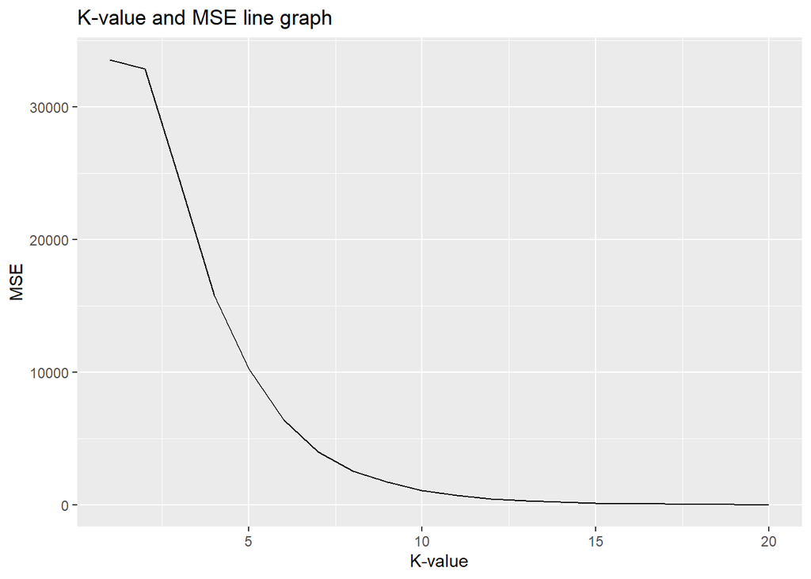

```r
# creating line graph
knn_mse |>
  ggplot(aes(k_value, mse)) + geom_line() + labs(x = "K-value", y = "MSE", title = "K-value and MSE line graph")
```

## Question 5

```r
set.seed(123) # Set seed

# Shuffle  data
shuffled_data <- taxi_data_encoded[sample(nrow(taxi_data_encoded)), ]

knn_ratio_test <- as.data.frame(matrix(nrow = 8, ncol = 2))
colnames(knn_ratio_test) <- c("MSE","Ratio")

for (i in 1:8) {
  ratio <- 0.8
  # Split data into training and test sets (80% training, 20% testing)
  split_index <- round(ratio * nrow(shuffled_data))
  training_set <- shuffled_data[1:split_index, ]
  test_set <- shuffled_data[(split_index + 1):nrow(shuffled_data), ]

  knn_ratio_test[i,2] <- ratio # Add ratio to dataframe
  ratio <- ratio - 0.1 # increment test ratio by -0.1

  knn_ratio_test[i,1] <- knn.predict(training_set, test_set, 3) # Add MSE to dataframe
}

knn_ratio_test
```

| MSE | Ratio |
| --- | --- |
| 24210.81 | 0.8 |
| 24561.04 | 0.8 |
| 24240.03 | 0.8 |
| 24033.34 | 0.8 |
| 24519.06 | 0.8 |
| 24325.80 | 0.8 |
| 24290.37 | 0.8 |
| 24137.82 | 0.8 |